# Heart Disease Data

> Cardiovascular diseases (CVDs) are the number 1 cause of death globally, taking an estimated 17.9 million lives each year, which accounts for 31% of all deaths worldwide. Four out of 5CVD deaths are due to heart attacks and strokes, and one-third of these deaths occur prematurely in people under 70 years of age. Heart failure is a common event caused by CVDs and this dataset contains 11 features that can be used to predict a possible heart disease.

```python
import pandas as pd
import numpy as np
import matplotlib.pyplot as plt
import seaborn as sb
%matplotlib inline
import warnings
warnings.filterwarnings('ignore')
```

```python
data = pd.read_csv("heart.csv")
print(data.shape)
print(data.dtypes)
print(data.head())
```

```
(918, 12)
Age                 int64
Sex                object
ChestPainType      object
RestingBP           int64
Cholesterol         int64
FastingBS           int64
RestingECG         object
MaxHR               int64
ExerciseAngina     object
Oldpeak           float64
ST_Slope           object
HeartDisease        int64
dtype: object
   Age Sex ChestPainType  RestingBP  Cholesterol  FastingBS RestingECG  MaxHR  \
0   40   M           ATA        140          289          0     Normal    172
1   49   F           NAP        160          180          0     Normal    156
2   37   M           ATA        130          283          0         ST     98
3   48   F           ASY        138          214          0     Normal    108
4   54   M           NAP        150          195          0     Normal    122

  ExerciseAngina  Oldpeak ST_Slope  HeartDisease
0              N      0.0       Up             0
1              N      1.0     Flat             1
2              N      0.0       Up             0
3              Y      1.5     Flat             1
4              N      0.0       Up             0
```

```python
data.isna().sum()
```

```
Age               0
Sex               0
ChestPainType     0
RestingBP         0
Cholesterol       0
FastingBS         0
RestingECG        0
MaxHR             0
ExerciseAngina    0
Oldpeak           0
ST_Slope          0
HeartDisease      0
dtype: int64
```

```python
data['HeartDisease'] = data['HeartDisease'].map({0:'normal',1:'heartDisease'})
data['FastingBS'] = data['FastingBS'].map({0:'>120',1:'other'})
```

> there is no null variable in this data

```python
print(data.describe())
```

```
              Age   RestingBP  Cholesterol       MaxHR     Oldpeak
count  918.000000  918.000000   918.000000  918.000000  918.000000
mean    53.510893  132.396514   198.799564  136.809368    0.887364
std      9.432617   18.514154   109.384145   25.460334    1.066570
min     28.000000    0.000000     0.000000   60.000000   -2.600000
25%     47.000000  120.000000   173.250000  120.000000    0.000000
50%     54.000000  130.000000   223.000000  138.000000    0.600000
75%     60.000000  140.000000   267.000000  156.000000    1.500000
max     77.000000  200.000000   603.000000  202.000000    6.200000
```

```python
cat_data = ['Sex','ChestPainType','RestingECG','ExerciseAngina','ST_Slope' , 'FastingBS']
int_data = ['Age','RestingBP','Cholesterol','MaxHR','Oldpeak']
```

#### **The structure of this data is**

###### 1- `Age`: age of the patient [years]

###### 2- `Sex`: sex of the patient [M: Male, F: Female]

###### 3- `ChestPainType`: chest pain type [TA: Typical Angina, ATA: Atypical Angina, NAP: Non-Anginal Pain, ASY: Asymptomatic]

###### 4- `RestingBP`: resting blood pressure [mm Hg]

###### 5- `Cholesterol`: serum cholesterol [mm/dl]

###### 6- `FastingBS`: fasting blood sugar [1: if FastingBS > 120 mg/dl, 0: otherwise]

###### 7- `RestingECG`: resting electrocardiogram results [Normal: Normal, ST: having ST-T wave abnormality (T wave inversions and/or ST elevation or depression of > 0.05 mV), LVH: showing probable or definite left ventricular hypertrophy by Estes' criteria]

###### 8- `MaxHR`: maximum heart rate achieved [Numeric value between 60 and 202]

###### 9- `ExerciseAngina`: exercise-induced angina [Y: Yes, N: No]

###### 10- `Oldpeak`: oldpeak = ST [Numeric value measured in depression]

###### 11- `ST_Slope`: the slope of the peak exercise ST segment [Up: upsloping, Flat: flat, Down: downsloping]

###### 12- `HeartDisease`: output class [1: heart disease, 0: Normal]`

## Univariate Exploration

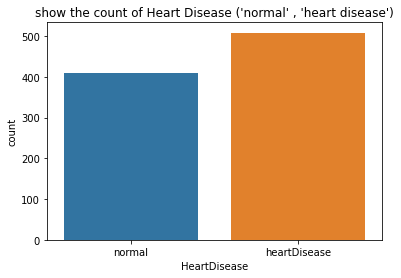

```python
# first i will explore the heart disease
sb.countplot(data = data , x = 'HeartDisease')
plt.xlabel('HeartDisease')
plt.ylabel("count")
plt.title("show the count of Heart Disease ('normal' , 'heart disease')");
```

> as wee see in this dataset that heart disease people > normal people it's approximately 500 people

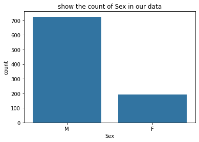

```python
# see categorical data counts in dataset
def my_cat_plot():
    for i in range(len(cat_data)):
        col_name = cat_data[i]
        default_color = sb.color_palette()[i]
        sb.countplot(data[col_name] ,  color = default_color)
        plt.ylabel("count")
        plt.xlabel(col_name)
        plt.title("show the count of {} in our data".format(col_name))
        yield

my_plot = my_cat_plot()
next(my_plot)
```

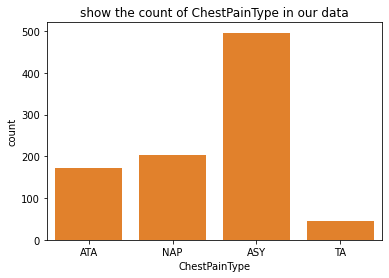

```python
next(my_plot)
```

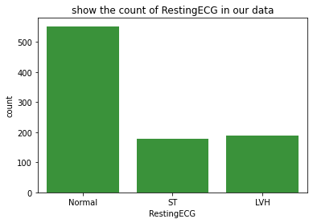

```python
next(my_plot)
```

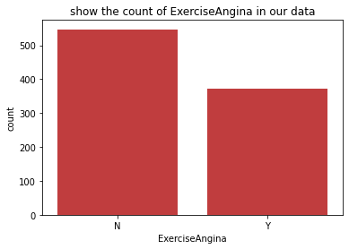

```python
next(my_plot)
```

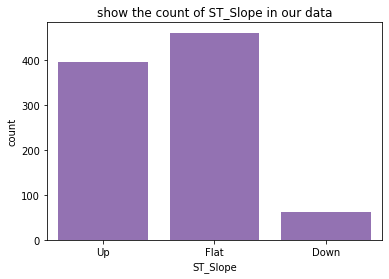

```python
next(my_plot)
```

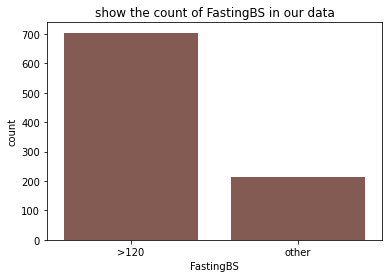

```python
next(my_plot)
```

###### we see here that male is larger than female and the difference between them is higher

###### we see here that ASY is the largers in chest pain type

###### we see here that normal is the largers in resting

###### we see here that N is the largers in exercise angina

###### we see here that flat is the largers in ST slope

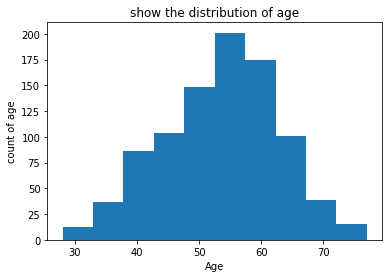

```python
## now let's explore the age
plt.hist(data['Age'])
plt.xlabel("Age")
plt.ylabel("count of age")
plt.title("show the distribution of age");
```

> the age data seems lik normal data

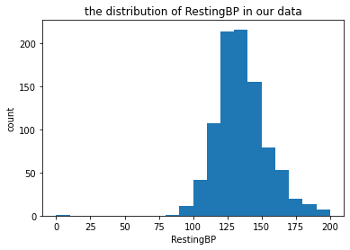

```python
# let's explore the other numeric data in this dataset
# fig, ax = plt.subplots(nrows=len(int_data)-1, figsize = [12,25])
def my_num_plot():
    for i in range(1,len(int_data)):
        col_name = int_data[i]
        bins = np.arange(min(data[col_name]), max(data[col_name])+10,10)
        default_color = sb.color_palette()[i-1]
        plt.hist(data[col_name]  , color = default_color , bins = bins )
        plt.xlabel(col_name)
        plt.ylabel("count")
        plt.title("the distribution of {} in our data".format(col_name))
        yield

my_plot =my_num_plot()
next(my_plot)
```

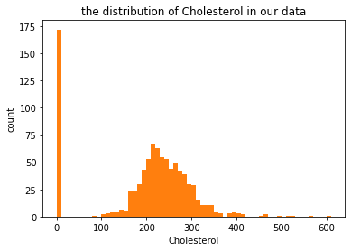

```python
next(my_plot)
```

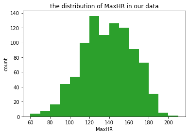

```python
next(my_plot)
```

[figure not shown]

```python
next(my_plot)
```

> here we see that there data have outliers RestingBP columns have outliers data

```python
outlier = (data['RestingBP'] < 100) | (data['RestingBP'] > 350)
print(data.loc[outlier,:])
print(outlier.sum())
```

[output not shown]

##### i didn't make any log trasnform in the data and each explore that i am get i write it under the plot so now let make a Bivariate Exploration

## Bivariate Exploration

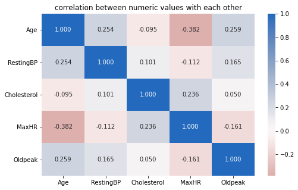

```python
# correlation plot
plt.figure(figsize = [8, 5])
sb.heatmap(data[int_data].corr(), annot = True, fmt = '.3f',
           cmap = 'vlag_r', center = 0)
plt.title("correlation between numeric values with each other");
plt.show()
```

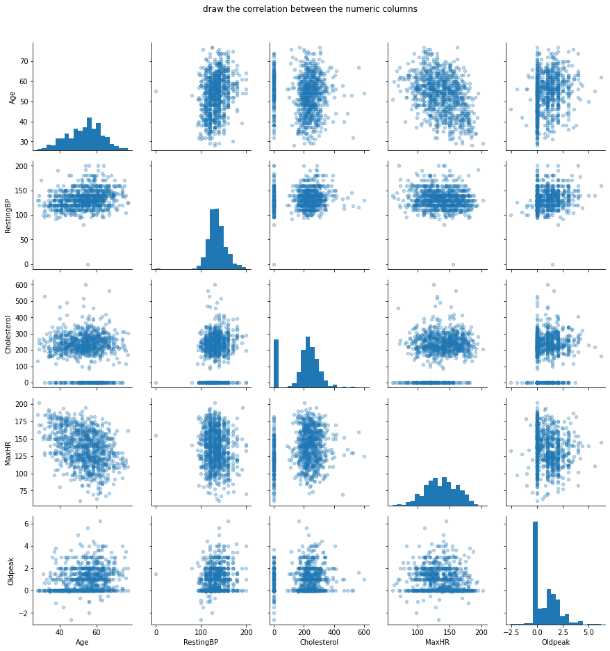

```python
# plot matrix: sample 500 diamonds so that plots are clearer and
# they render faster
g = sb.PairGrid(data = data[int_data], vars = int_data)
g = g.map_diag(plt.hist, bins = 20 );
g.map_offdiag(plt.scatter, alpha = 0.3 , s = 20)
plt.suptitle("draw the correlation between the numeric columns", y = 1.04);
```

##### we should put in our mind that the heart disease columns only have 2 values 0 or 1

```python
def myplot_iterator():
    for i in range(len(cat_data)):
        def_color = sb.color_palette()[i]
        var = cat_data[i]
        plt.figure(figsize = [14,8])
        sb.countplot(data = data, x =var , hue = 'HeartDisease' )
        plt.title("compare bewtween number of normal and disease people by {}".format(var));
        plt.legend()

        yield
```

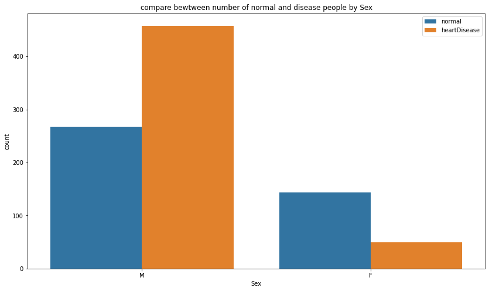

```python
myplot = myplot_iterator()
next(myplot)
```

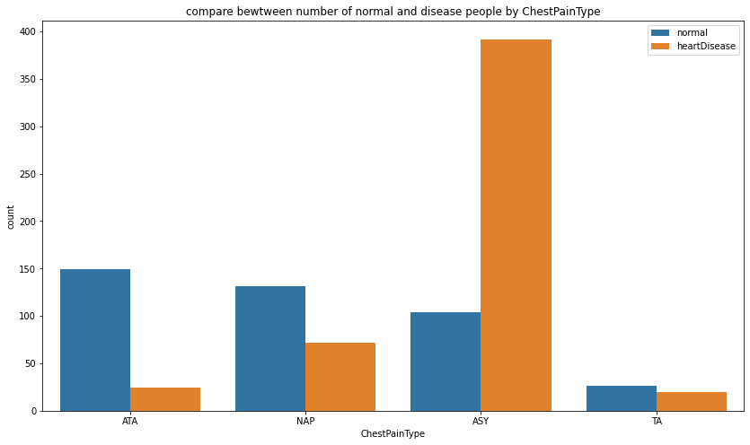

```python
next(myplot)
```

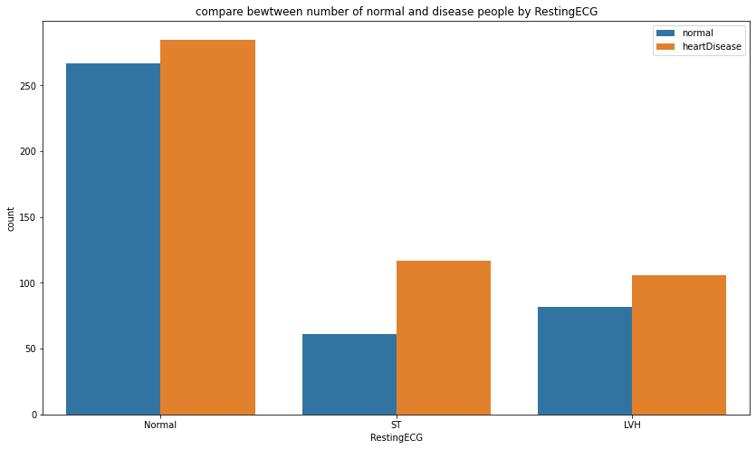

```python
next(myplot)
```

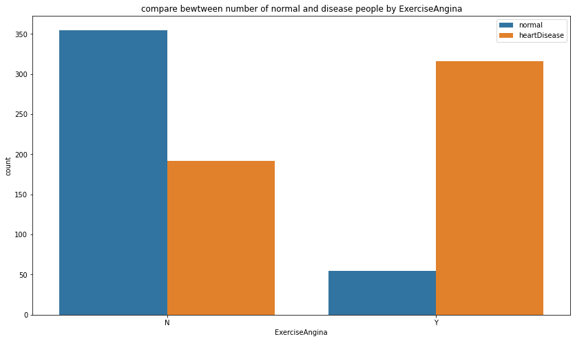

```python
next(myplot)
```

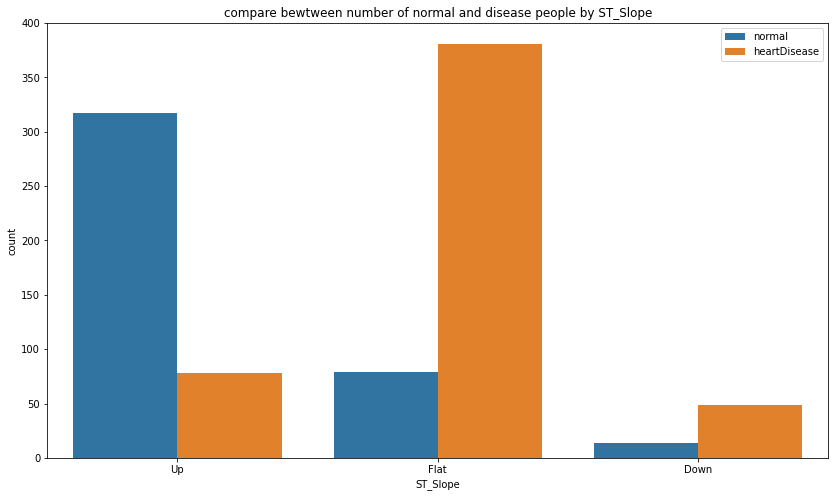

```python
next(myplot)
```

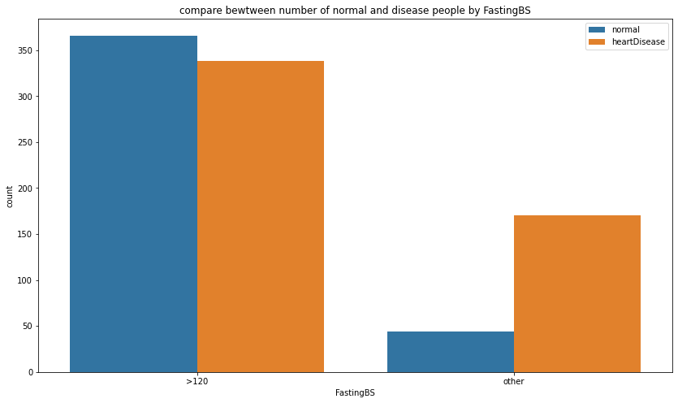

```python
next(myplot)
```

###### 2- most of people that have heart disease are have ASY chest pain

###### 3- also most of them are have st slope flat

## Multivariate Exploration

##### let's do Multivariate Exploration for all features with each other by hueristic heart disease to see population of people that have heart disease

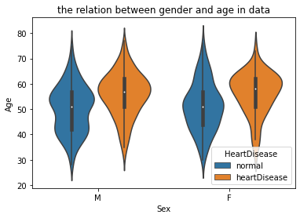

```python
# let's try gender with age
sb.violinplot(data = data , x = 'Sex',y = 'Age', hue = 'HeartDisease' )
plt.title("the relation between gender and age in data");
```

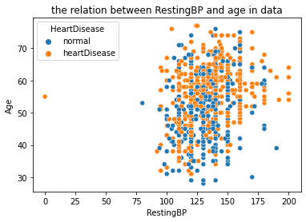

```python
sb.scatterplot(data = data , y = 'Age',x = 'RestingBP', hue = 'HeartDisease' )
plt.title("the relation between RestingBP and age in data");
```

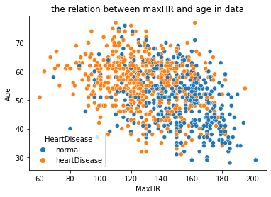

```python
sb.scatterplot(data = data , y = 'Age',x = 'MaxHR', hue = 'HeartDisease' )
plt.title("the relation between maxHR and age in data");
```

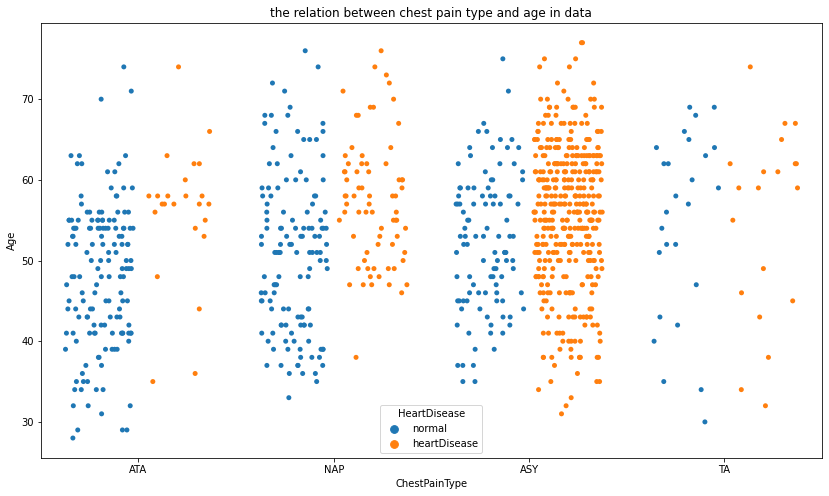

```python
plt.figure(figsize = [14,8])
sb.stripplot(data = data , y = 'Age',x = 'ChestPainType', hue = 'HeartDisease',
            jitter = 0.35 , dodge = True)
plt.title("the relation between chest pain type and age in data");
```

#### Were there any interesting or surprising interactions between features?

> there is relation between age and maxhr only in the numeric data when we see at catergorical data we will see that chast pain type ASY have high relation with the people that have heart disease and also there is relation between male people that over 60 years old most of them have heart disease also